# 王晨曦

2019-12-20

第一届研究生入学四十周年  
——推免和保研的现状如何？

数据可视化期末作业

# 研究生恢复招生四十周年：变化翻天覆地

[figure not shown]

1978 年 1 月 26 日，随着教育部下发《关于 1979 年研究生招生工作的通知》，我国正式恢复研究生招生。由于十年动乱影响，优秀生源严重不足。为了保证入学质量，1979 年和 1980 年的全国研究生招生计划都没有完成。如今，研究生招生已经走过个 41 个年头，研究生规模与招生方式都发生了翻天覆地的变化。

从规模上来讲，2018 年研究生招生数量达到 85.8 万人，相较于 40 年前增加了 106 倍。研究生在校生数量达到 272.3 万人，增加 45 倍$^1$。 90 年代后，研究生招生实现稳步增长。

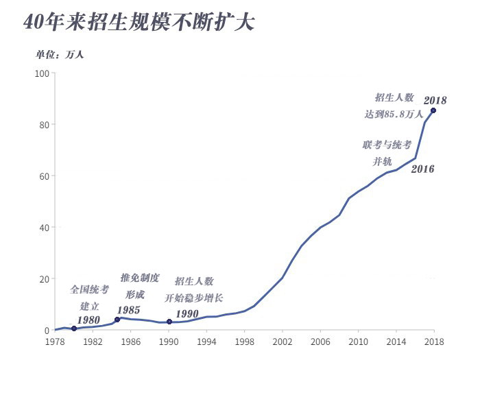

从招生方式来讲，研究生招生选拔模式经过近 40 年的发展和调整，形成了四种模式:一是初试统考加复试;二是初试单考加复试;三是初试联考加复试;四是推荐免试加复试。复试由各学校分别举行，这四种模式的区别主要在于初试的形式。

一般而言，在职研究生的入学途径为单考和联考。单考的所有科目由院校自主命题、难度较低，单考必须到报考院校所在地参加考试；联考则是每年 10 月份针对在职研究生的一次统一考试，区别于统考，学生完成考试毕业后只能获取专业硕士学位，不能取得研究生学历。全日制研究生则主要通过统考（即每年12月份的研究生统一考试）和推免（即推荐免试）进行选拔。

1980 年，公共课和部分专业基础课首次实行全国统一命题，真正意义上的全国统考制度由此建立。1985 年，我国首次在 169 所高校中试点施行推荐优秀应届本科毕业生免试就读研究生的政策，在这些高校中共有 3300 人获得推免资格，推免制度从此成为一种固定的选拔模式。随着我国的高等教育步入大众化阶段，研究生教育不断扩招，越来越多的本科生选择毕业后继续深造，推高了统考和推免模式的占比。如今，统考和推免已经成为我国研究生选拔的两种主流模式$^2$。

$1$. 数据来源：国家统计局  
$2$. 秦国柱, 孙志远. 改革开放40年来研究生招生选拔模式变革趋势、问题及对策[J]. 黑龙江高教研究, 2019, 37(05):104-110.

# 推免：这真的是一条捷径？

12 月 21 日， 2019 年研究生考试即将拉开帷幕。正值冲刺阶段，图书馆、自习室随处可见埋头苦读的应届生，他们都是“考研大军”中的一员，与千万考生在这场没有硝烟的战争中一起争夺“上岸”的资格。然而在这时，另一部分应届生已经顺利拿到了推免资格，手握心仪高校的“入场券”。

我国自 1985 年开始施行推免政策。推免指的是“经审定可以开展推免生工作的高等学校，可以推荐该校规定数量的优秀应届本科毕业生免初试。”

随着高等教育大众化、研究生招生体系多元化，推免生占比呈现不断扩大的趋势。某些双一流高校目前招收的学生中，推免生占比 已经超过了 50%$^3$。以 2020 年在 QS 亚洲大学排名中跃升至第六位的浙江大学为例，2017 年招生推免生占比为 49%，到 2019 年推免生占比增加到了 54%，超过半数$^4$。

2018年8月，随着教育部办公厅印发《关于 2017 年新增推荐优秀应届本科毕业生免试攻读研究生普通高等学校予以备案的通知》，具有保研资格的大学已经从 312 所增加到了 366 所，其中辽宁，北京，山东数量增加最多，三省综合达到13所。 现有保研高校中，分布在北京的数量最多，达到 45 所。其次是辽宁 25 所、江苏 25 所、上海 19 所$^5$。

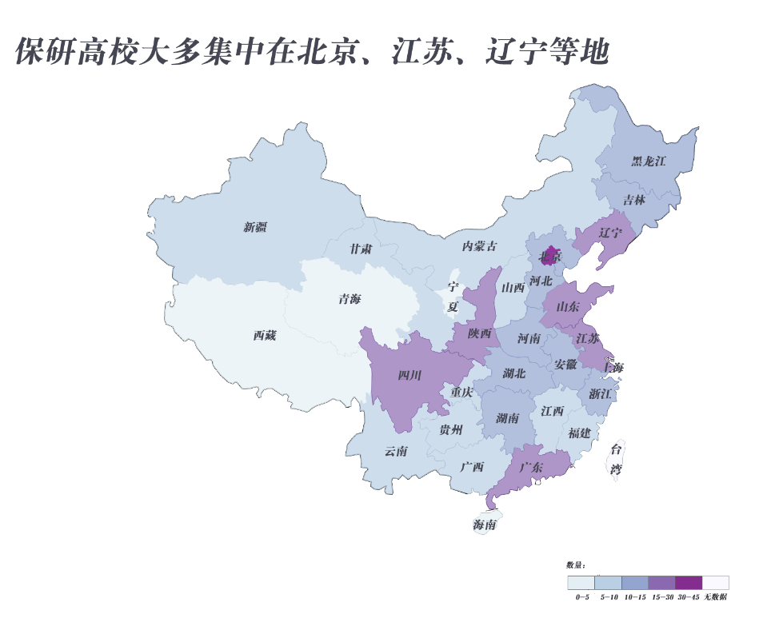

整体保研率逐年递增，但各个学校的情况相差甚远。在这 366 所高校中，保研率最高的超过了 50% ，最低的不过2%-3%(每年有浮动)。以有公开数据的 40 所高校为例，2020 年 985 高校的平均保研率为 26.89%；211 高校为 13.29%；普通本科高校则为 8%。从下图可以看出，各个 985 高校的保研率均高于 211 高校和普通本科高校。

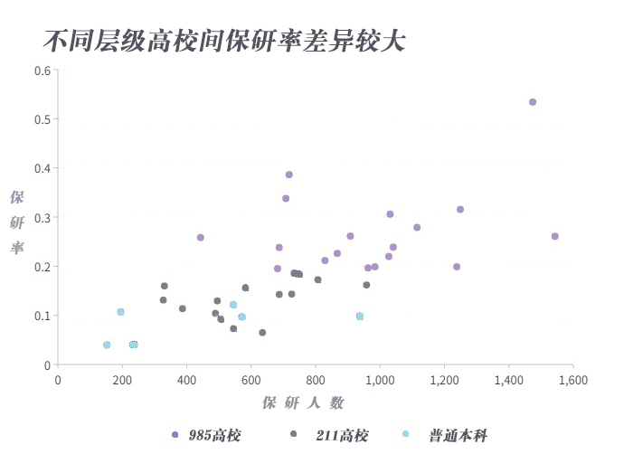

按照教育部的规定，设有研究生院的高校，保送研究生名额一般按该校应届本科毕业生数 15% 左右确定。对未设立研究生院的“211 工程”高校，这个数字是 5% 左右，非“211”工程高校则更少，只有 2%。而经教育部确定的人文、理科等人才培养基地的高等学校，可单独增加推免生名额，由学校统筹安排。总的来说，不同层级的高校有不同的标准，各高校可以在标准之下进行少量调整，“名校“和”普通高校“之间保研率还是存在巨大差异。

对于将“读研”作为最终目标的人来说，眼前只有考研和保研两条路选择。相对于“千军万马过独木桥”的考研来说，能够免去初试且几乎无风险升学的保研，似乎是一条捷径：不用经历一年紧张挣扎的备考、不用面临残酷的竞争、不用害怕失败的风险。然而，这条捷径当真走的轻松吗？

成功保研至中国人民大学的大四学生赵玥说，如果说考研是一场没有硝烟的战争，那么保研之路就是一场长达三年的拉锯战。赵玥本科所在的是一所普通的一本类大学，平均保研率在 5%，一个专业大类的 100 人中只有不到 5 人能成功保研。保研名额并没有那么好拿，除了成绩要始终稳定在前 5%，大学前三年还需按照学校要求参加各类比赛及社团活动等，最好还要有科研成果及论文的发表，总之就是“要当一个德智体美劳全面发展的好学生。”她说，“整个大学我几乎没有给过自己什么假期，除了学习就是在参加比赛。”

赵玥从今年3月份开始关注各个高校的夏令营信息，3-6 月份都忙于准备材料、投递材料。7-8月份的时间不间断地奉献给了三个学校的夏令营，拿到了其中两个学校的保研资格。9-10月份参加学校复试，7-9 月份也一直在为了复试的要求看书、学习，记不清熬了多少个夜。“除了学习上的煎熬，心理上的煎熬更令人难受：能不能保研、能不能过复试都是到最后才知道。即使出了结果，我也直到 9 月 28 日系统填报结束才真正放下心来。”

除了为之付出的心力，保研的竞争同样激烈。尽管有清华北大这样保研率超过百分之五十的学校，但毕竟全国这样的高校只有两所。大多数的高校保研率不足 10%，这其中还包括特殊人才保研、支教保研等以其他方式通过保研的学生。想要在经过同样筛选的一群学生中始终保持前列，也并非易事。

赵玥最后说到，大家都觉得保研是一条给自己免去许多“辛苦”的捷径，但是她这几年为保研付出的或许并不比考研来得少。保研路上忍受的是细碎绵长的竞争与压力，这也是一条“一条路走到黑的独木桥”。同时，保研确实存在局限性，一般只能保到本专业或本专业相关专业，还有可能会保到不如本科学校的高校，相对来说，考研有更大的选择余地。

$3$. 此处的推免生占比指的是推免生占研究生院招生总人数的比例  
$4$. 数据来源：中国教育在线  
$5$. 数据来源：跨考考研

# 考研：趋势一直在变化，难度一直在增加

2017 年，教育部、国务院学位委员会印发的《学位与研究生教育发展“十三五”规划》中明确指出，保持研究生培养规模适度增长，到 2020 年，在学研究生总规模达到 290 万人。

但扩招并没有为考生减小压力。招生人数增加的同时，由于报名人数的增长与保研率的提高，报录比在 3 左右不定增减，并未增加$^6$。

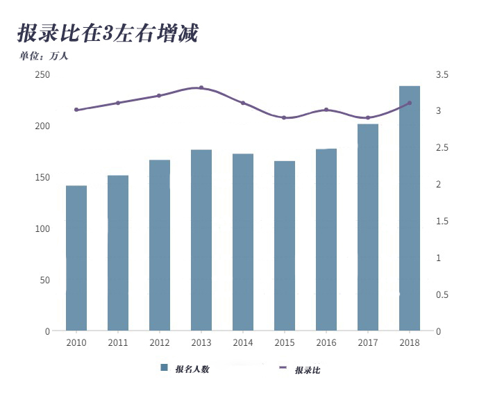

除了扩招的诱导外，本科毕业人数的增加也是报名人数增加的一大原因。2009 年高校本科毕业生人数为 246 万，2012 年超过 300 万，到了 2018 年达到了 387 万。毕业人数的飞涨使本科学历含金量与日俱减、就业起点变高、就业竞争加剧。根据中国教育在线发布的《2019 年全国研究生招生调查报告》显示，考生在报考研究生时，首要动机为就业压力大，36% 的学生为了提高就业竞争力选择考研。

“当考研难度越来越大，报录比越来越低的时候，我们面临的压力也越来越大。同时，我感觉我们这一代学生更多人把拿到学历当作自己的目的，拿到学位超越学术理想成为首要标准。”正在考研的大四新闻学学生赵荣说道。

相对于应届生，就业竞争对往届生的影响更加明显。

近年来往届生的占比与日俱增。往届生指的是非应届毕业的学生，往届生考研一般有两种情况：第一次考研没有成功，选择二战、三战……或是就业后发现竞争力不足、工作需要等其他原因，选择考研。2017年，往届生考研人数占全国报考人数的43.8%，2018 年，往届生考研人数占全国报考人数的 45%，同比上升了 1.2%。以变化最明显的河北省为例，河北省 2015 年往届生所占比例为 29.3%，到 2019 年这个比例升至 44.2%。

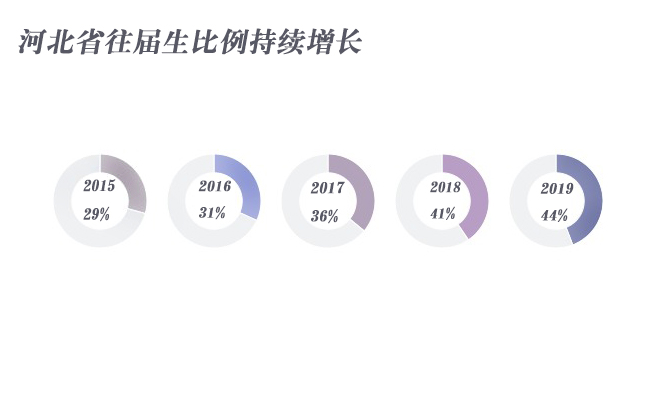

除了往届生比例提高，报考专硕的人数增加也一大特征。专硕即专业硕士，相对学硕，专硕更偏重技术实践，注重理论与实践相结合。为了解决大学生日益突出的就业问题，我国从2009年开始全面招收全日制专业学位硕士研究生，在扩招之初，由于社会对专硕的认可度不高，所以专业学位研究生比例并不高。后来，基于专硕越来越受到社会认可、专硕考试难度降低等诸多因素，专业硕士研究生规模持续扩大，在2017年招生人数首次超过学术型研究生$^7$。

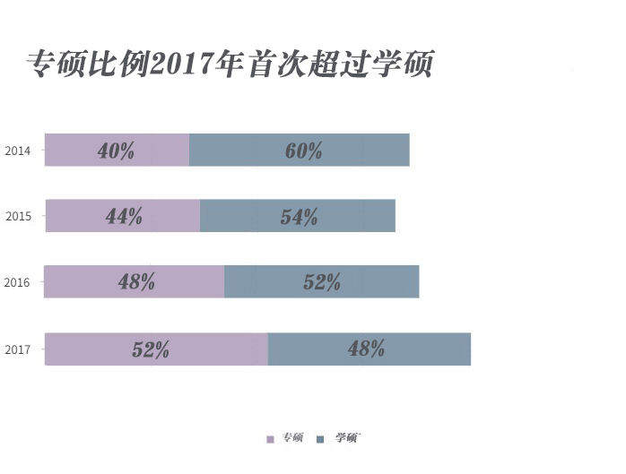

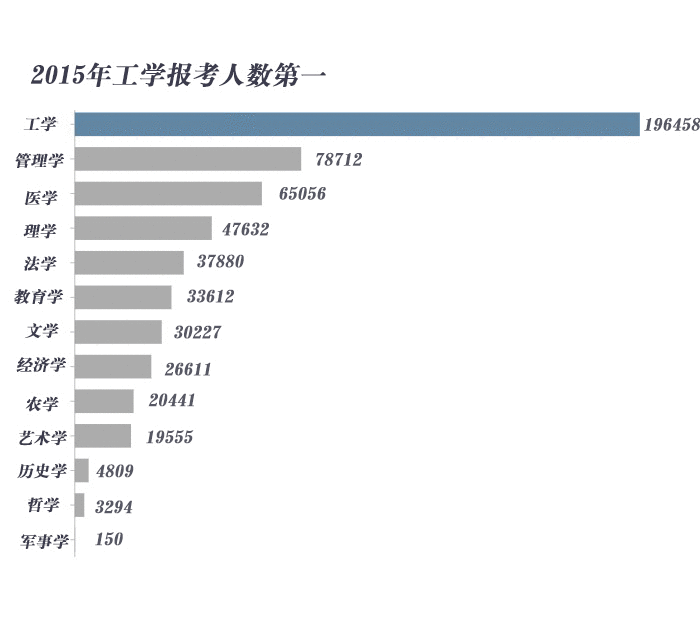

值得说明的是，专业的热门程度与最终的报录比并没有直接关系。简单来说，热门不意味着难考，竞争对手少也不意味着容易。以浙江大学 2019 年硕士各专业报录比为例，除去无人报考的专业，报录比最高的学科及其比例分别为船舶与海洋工程（工学）0.48、资源利用与海洋保护（理学）0.56 和海洋物理学(理学) 0.64，工学和理学虽然报考人数多，但报录比并不高。而最低的分别为心理学（教育学）84.6、药学（医学）51.8和计算机科学与技术（工学）39.9$^8$。

其中，新闻与传播学等四个专业的报录比也超过了 28，也就是说，28 个人里，只有一个人能够被录取。各专业的报录比或多或少影响着考生的选择，赵荣选择了考本校新闻传播方向的研究生。他说，新闻专业历年报录比都不算很高，跨考的风险太大，考本校的专业比较有把握。他身边大多数同学也都选择了考本校的研究生。

$6$. 数据来源：中国教育在线  
$7$. 数据来源：教育部发展规划司  
$8$. 数据来源：浙江大学研究生招生官网

# 尾声：丢掉迷茫，做出最合适的选择

距离第一届研究生入学已经过去了整整四十年。在这四十年中，各种规定不断出台，研究生招生情况随着社会现实变化不断变迁，招生体制也在变化中不断完善。

12 月 21 日（明天），2020 年研究生统考拉开序幕。这意味着应届生们即将结束这场艰苦的“战役“，也意味着新的一批大学生即将迎来他们的读研选择。

保研的不确定性与考研的难度增大是无法扭转的大趋势，每一年的招生简章和招生政策都在发生或大或小的改变，但对于希望攻读研究生的大学生而言，了解情况-明确目标-不断学习的过程却是一直适用的。

**参考文献**

[1]秦国柱,孙志远.改革开放40年来研究生招生选拔模式变革趋势、问题及对策[J].黑龙江高教研究,2019,37(05):100-106.  
[2]杨楠.新中国成立70周年系列——北京高校研究生规模(1978年—2018年)[J].北京教育(高教),2019(11):4-5.

**数据来源**

1. 中国教育在线
2. 教育部发展规划司
3. 各学校研究生招生官网
4. 国家统计局
5. 中国研究生招生信息网
6. 考研跨考网